# Football Match Outcome Classification

Replication of ML2 Python Project in R

Authors

Ashutosh Kumar Verma (475852)

Ramik Sharma (477656)

Published

May 13, 2026

```r
library(here)
library(tidyverse)
library(lubridate)
library(tidymodels)
library(themis)
library(ranger)
library(xgboost)
library(stacks)
library(yardstick)
library(patchwork)
library(knitr)
```

# 1 Introduction

## 1.1 Project Overview

This report replicates in **R** the Football Match Outcome Classification project originally developed in Python for the ML2 – Machine Learning 2 course (Rajat Dogra & Umair Aziz, January 2026).

**Objective:** Predict football match outcomes — Home Win, Draw, or Away Win — using historical match data from ESPN Soccer (2024–2026).

**Research question:** Can institutional and contextual match features (team strength, venue, league, temporal patterns) reliably predict football match outcomes using machine learning?

## 1.2 Python Baseline

| Model | Accuracy | F1-Score | AUC |
| --- | --- | --- | --- |
| Random Forest | 62.87% | 0.6267 | 0.8176 |
| Gradient Boosting | 64.16% | 0.6412 | 0.8265 |
| XGBoost | 64.84% | 0.6476 | 0.8326 |
| Neural Network | 59.45% | 0.5941 | 0.7758 |
| **Stacking Ensemble** | **65.36%** | **0.6533** | **0.8347** |

# 2 Data Loading & Exploration

```r
df <- read_csv(here("classification", "data", "fixtures.csv"),
               show_col_types = FALSE)

cat("Dataset dimensions:", nrow(df), "rows x", ncol(df), "columns\n")
```

```
Dataset dimensions: 67353 rows x 17 columns
```

```r
cat("Expected: 67,353 rows\n")
```

```
Expected: 67,353 rows
```

## 2.1 Create Outcome Variable

```r
df <- df %>%
  mutate(
    outcome = case_when(
      homeTeamWinner == TRUE ~ "Home Win",
      awayTeamWinner == TRUE ~ "Away Win",
      TRUE                   ~ "Draw"
    )
  )
```

## 2.2 Drop Leakage Columns

```r
leakage_cols <- c(
  "homeTeamWinner", "awayTeamWinner",
  "homeTeamScore", "awayTeamScore",
  "homeTeamShootoutScore", "awayTeamShootoutScore",
  "statusId"
)

leakage_cols <- leakage_cols[leakage_cols %in% names(df)]
df <- df %>% select(-all_of(leakage_cols))

cat("Dropped", length(leakage_cols), "leakage columns\n")
```

```
Dropped 7 leakage columns
```

```r
cat("Remaining columns:", ncol(df), "\n")
```

```
Remaining columns: 11
```

## 2.3 Class Distribution

```r
class_dist <- df %>%
  count(outcome) %>%
  mutate(percentage = round(n / sum(n) * 100, 2))

kable(class_dist,
      caption = "Outcome Class Distribution",
      col.names = c("Outcome", "Count", "Percentage (%)"))
```

Outcome Class Distribution

| Outcome | Count | Percentage (%) |
| --- | --- | --- |
| Away Win | 17832 | 26.48 |
| Draw | 22980 | 34.12 |
| Home Win | 26541 | 39.41 |

## 2.4 Missing Values

```r
missing_summary <- df %>%
  summarise(across(everything(), ~sum(is.na(.)))) %>%
  pivot_longer(everything(),
               names_to = "Column",
               values_to = "Missing") %>%
  filter(Missing > 0)

if (nrow(missing_summary) == 0) {
  cat("No missing values found\n")
} else {
  kable(missing_summary, caption = "Columns with Missing Values")
}
```

```
No missing values found
```

## 2.5 EDA Visualisations

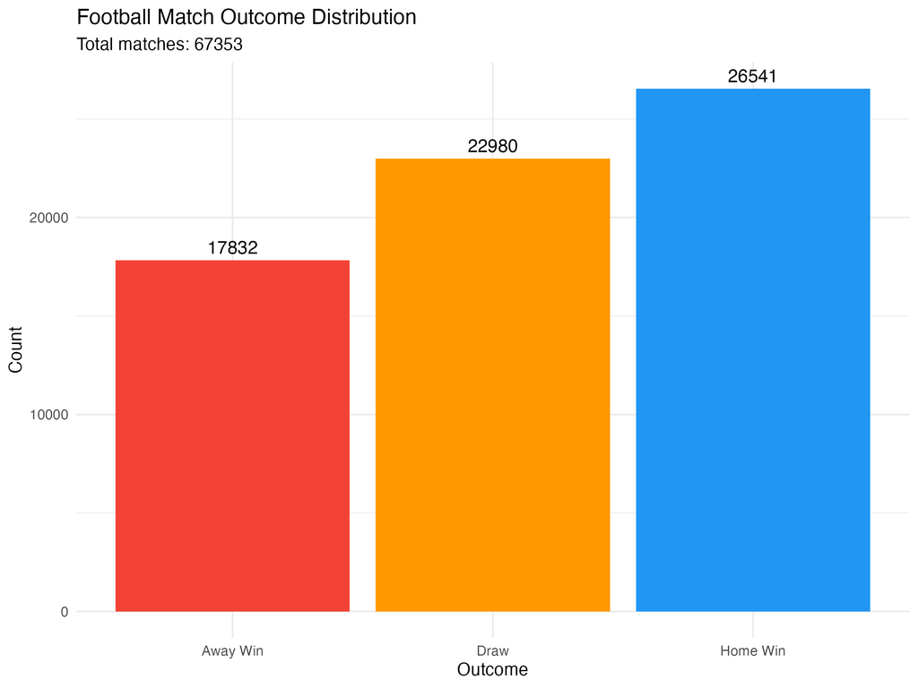

Match Outcome Distribution

```r
knitr::include_graphics(
  here("classification", "output", "outcome_distribution.png"))
```

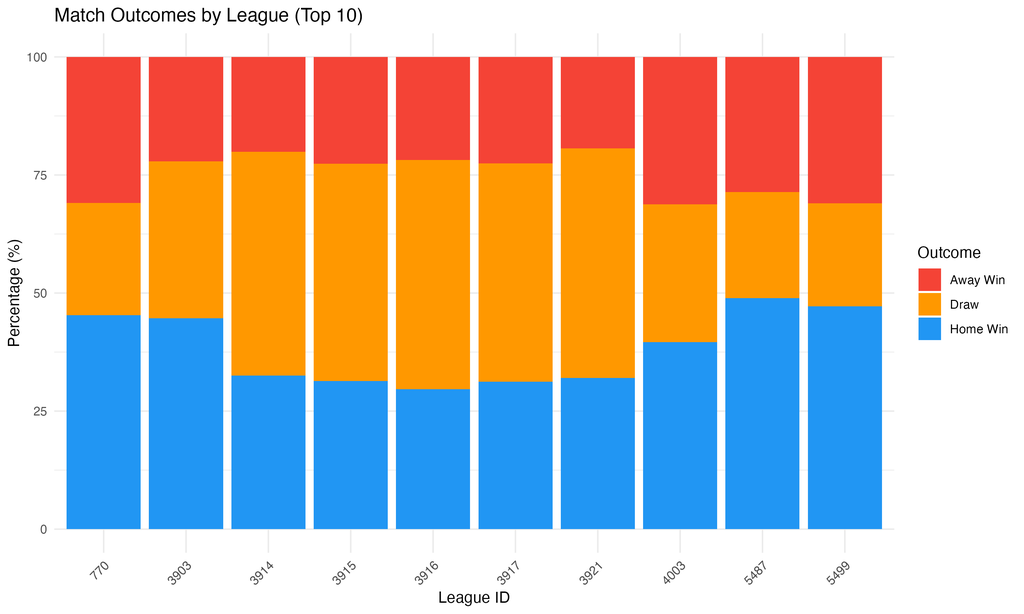

Match Outcomes by League (Top 10)

```r
knitr::include_graphics(
  here("classification", "output", "outcomes_by_league.png"))
```

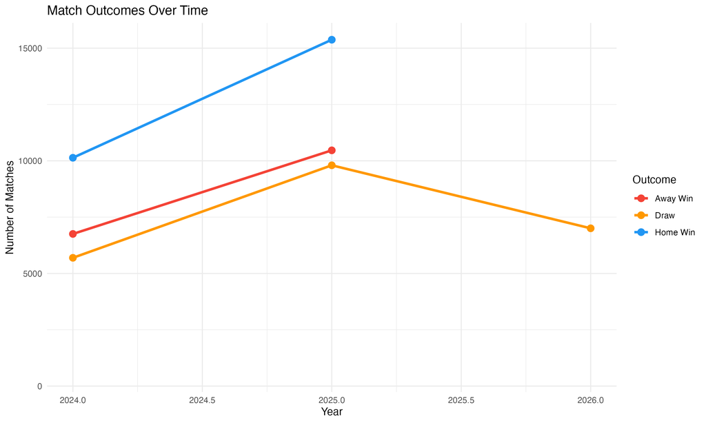

Match Outcomes Over Time

```r
knitr::include_graphics(
  here("classification", "output", "temporal_trends.png"))
```

# 3 Feature Engineering

```r
df <- df %>%
  mutate(date = ymd_hms(date, quiet = TRUE)) %>%
  arrange(date)
```

## 3.1 Temporal Features

```r
df <- df %>%
  mutate(
    month             = month(date),
    day_of_week       = wday(date, label = FALSE),
    hour              = hour(date),
    is_weekend        = if_else(wday(date) %in% c(1, 7), 1, 0),
    quarter           = quarter(date),
    season            = case_when(
      month %in% c(8, 9, 10, 11, 12) ~ "early_season",
      month %in% c(1, 2, 3, 4, 5)    ~ "late_season",
      TRUE                            ~ "off_season"
    ),
    is_holiday_season = if_else(month %in% c(12, 1), 1, 0)
  )

cat("Temporal features created: month, day_of_week, hour, is_weekend,",
    "quarter, season, is_holiday_season\n")
```

```
Temporal features created: month, day_of_week, hour, is_weekend, quarter, season, is_holiday_season
```

## 3.2 Team Performance Features

```r
df <- df %>% arrange(date)

home_stats <- df %>%
  group_by(homeTeamId) %>%
  mutate(
    home_team_win_rate   = lag(cumsum(outcome == "Home Win") /
                                 row_number(), default = 0),
    home_team_draw_rate  = lag(cumsum(outcome == "Draw") /
                                 row_number(), default = 0),
    home_team_experience = lag(row_number(), default = 0)
  ) %>%
  ungroup() %>%
  select(eventId, home_team_win_rate,
         home_team_draw_rate, home_team_experience)

away_stats <- df %>%
  group_by(awayTeamId) %>%
  mutate(
    away_team_win_rate   = lag(cumsum(outcome == "Away Win") /
                                 row_number(), default = 0),
    away_team_draw_rate  = lag(cumsum(outcome == "Draw") /
                                 row_number(), default = 0),
    away_team_experience = lag(row_number(), default = 0)
  ) %>%
  ungroup() %>%
  select(eventId, away_team_win_rate,
         away_team_draw_rate, away_team_experience)

df <- df %>%
  left_join(home_stats, by = "eventId") %>%
  left_join(away_stats, by = "eventId")
```

## 3.3 Derived Strength Metrics

```r
df <- df %>%
  mutate(
    strength_difference   = home_team_win_rate - away_team_win_rate,
    combined_strength     = home_team_win_rate + away_team_win_rate,
    experience_difference = home_team_experience - away_team_experience
  )
```

## 3.4 League & Venue Features

```r
league_stats <- df %>%
  group_by(leagueId) %>%
  summarise(
    league_home_advantage = mean(outcome == "Home Win", na.rm = TRUE),
    league_draw_rate      = mean(outcome == "Draw",     na.rm = TRUE),
    league_size           = n(),
    .groups = "drop"
  )

venue_stats <- df %>%
  group_by(venueId) %>%
  summarise(
    venue_home_advantage = mean(outcome == "Home Win", na.rm = TRUE),
    venue_usage          = n(),
    .groups = "drop"
  )

h2h_stats <- df %>%
  mutate(matchup_id = paste(pmin(homeTeamId, awayTeamId),
                            pmax(homeTeamId, awayTeamId), sep = "_")) %>%
  group_by(matchup_id) %>%
  summarise(h2h_frequency = n(), .groups = "drop")

df <- df %>%
  left_join(league_stats, by = "leagueId") %>%
  left_join(venue_stats,  by = "venueId") %>%
  mutate(matchup_id = paste(pmin(homeTeamId, awayTeamId),
                            pmax(homeTeamId, awayTeamId), sep = "_")) %>%
  left_join(h2h_stats, by = "matchup_id") %>%
  select(-matchup_id)
```

## 3.5 Final Feature Set

```r
model_features <- c(
  "leagueId", "venueId", "homeTeamId", "awayTeamId",
  "month", "day_of_week", "hour", "is_weekend",
  "quarter", "season", "is_holiday_season",
  "home_team_win_rate", "away_team_win_rate",
  "home_team_draw_rate", "away_team_draw_rate",
  "home_team_experience", "away_team_experience",
  "strength_difference", "combined_strength", "experience_difference",
  "league_home_advantage", "league_draw_rate", "league_size",
  "venue_home_advantage", "venue_usage",
  "h2h_frequency"
)

df_model <- df %>%
  select(all_of(model_features), outcome) %>%
  mutate(
    outcome    = factor(outcome, levels = c("Home Win", "Draw", "Away Win")),
    leagueId   = factor(leagueId),
    venueId    = factor(venueId),
    homeTeamId = factor(homeTeamId),
    awayTeamId = factor(awayTeamId),
    season     = factor(season)
  ) %>%
  drop_na()

cat("Total features:", length(model_features), "\n")
```

```
Total features: 26
```

```r
cat("Rows after dropping NAs:", nrow(df_model), "\n")
```

```
Rows after dropping NAs: 65228
```

## 3.6 Train/Test Split & SMOTE

```r
set.seed(42)
data_split <- initial_split(df_model, prop = 0.8, strata = outcome)
train_data <- training(data_split)
test_data  <- testing(data_split)

cat("Training set:", nrow(train_data), "rows\n")
```

```
Training set: 52182 rows
```

```r
cat("Testing set: ", nrow(test_data),  "rows\n")
```

```
Testing set:  13046 rows
```

```r
kable(
  as.data.frame(table(train_data$outcome)),
  caption = "Class distribution in training set",
  col.names = c("Outcome", "Count")
)
```

Class distribution in training set

| Outcome | Count |
| --- | --- |
| Home Win | 20408 |
| Draw | 17999 |
| Away Win | 13775 |

```r
rec <- recipe(outcome ~ ., data = train_data) %>%
  step_other(leagueId, venueId, homeTeamId, awayTeamId,
             threshold = 0.01) %>%
  step_dummy(leagueId, venueId, homeTeamId, awayTeamId, season) %>%
  step_normalize(all_numeric_predictors()) %>%
  step_smote(outcome, over_ratio = 1)

rec_prepped  <- prep(rec, training = train_data)
train_baked  <- bake(rec_prepped, new_data = NULL)

cat("After SMOTE — class distribution:\n")
```

```
After SMOTE — class distribution:
```

```r
print(table(train_baked$outcome))
```

```
Home Win     Draw Away Win
   20408    20408    20408
```

# 4 Model Training & Evaluation

```r
output_dir    <- here("classification", "output")
eval_results  <- readRDS(file.path(output_dir, "eval_results.rds"))
all_per_class <- readRDS(file.path(output_dir, "all_per_class.rds"))
cm_best       <- readRDS(file.path(output_dir, "cm_best.rds"))
per_class     <- readRDS(file.path(output_dir, "per_class_best.rds"))
outcome_levels <- c("Home Win", "Draw", "Away Win")
best_name     <- eval_results$model[which.max(eval_results$accuracy)]
```

## 4.1 Model Comparison

Five models were trained using 5-fold stratified cross-validation:

```r
eval_display <- eval_results %>%
  mutate(
    Accuracy  = sprintf("%.2f%%", accuracy * 100),
    F1_Score  = sprintf("%.4f",   f1_weighted),
    AUC       = sprintf("%.4f",   auc)
  ) %>%
  select(Model = model, Accuracy, F1_Score, AUC)

kable(eval_display,
      caption = "Test Set Performance — All Models",
      align   = c("l", "r", "r", "r"))
```

Test Set Performance — All Models

| Model | Accuracy | F1_Score | AUC |
| --- | --- | --- | --- |
| Random Forest | 55.69% | 0.5605 | 0.7431 |
| Gradient Boosting | 56.34% | 0.5607 | 0.7424 |
| XGBoost | 57.20% | 0.5688 | 0.7492 |
| Neural Network | 53.66% | 0.5384 | 0.7234 |
| Stacking Ensemble | 57.30% | 0.5653 | 0.7504 |

## 4.2 Comparison with Python Baseline

```r
comparison <- tibble(
  Model = c("Random Forest", "Gradient Boosting",
            "XGBoost", "Neural Network", "Stacking Ensemble"),
  R_Accuracy    = sprintf("%.2f%%", eval_results$accuracy * 100),
  Python_Accuracy = c("62.87%", "64.16%", "64.84%", "59.45%", "65.36%"),
  R_F1      = sprintf("%.4f", eval_results$f1_weighted),
  Python_F1 = c("0.6267", "0.6412", "0.6476", "0.5941", "0.6533")
)

kable(comparison,
      caption = "R vs Python Baseline Comparison",
      align   = c("l", "r", "r", "r", "r"))
```

R vs Python Baseline Comparison

| Model | R_Accuracy | Python_Accuracy | R_F1 | Python_F1 |
| --- | --- | --- | --- | --- |
| Random Forest | 55.69% | 62.87% | 0.5605 | 0.6267 |
| Gradient Boosting | 56.34% | 64.16% | 0.5607 | 0.6412 |
| XGBoost | 57.20% | 64.84% | 0.5688 | 0.6476 |
| Neural Network | 53.66% | 59.45% | 0.5384 | 0.5941 |
| Stacking Ensemble | 57.30% | 65.36% | 0.5653 | 0.6533 |

## 4.3 Best Model Performance

```r
cat("Best model:", best_name, "\n")
```

```
Best model: Stacking Ensemble
```

```r
best_row <- eval_results %>% filter(model == best_name)
cat(sprintf("Accuracy: %.2f%%\n", best_row$accuracy * 100))
```

```
Accuracy: 57.30%
```

```r
cat(sprintf("F1-Score: %.4f\n",   best_row$f1_weighted))
```

```
F1-Score: 0.5653
```

```r
cat(sprintf("AUC:      %.4f\n",   best_row$auc))
```

```
AUC:      0.7504
```

## 4.4 Per-Class Metrics

```r
kable(per_class,
      caption = sprintf("Per-class Metrics — %s", best_name),
      digits  = 4,
      col.names = c("Class", "Precision", "Recall", "F1"))
```

Per-class Metrics — Stacking Ensemble

[output not shown]

# 5 Visualisations

## 5.1 Model Performance Dashboard

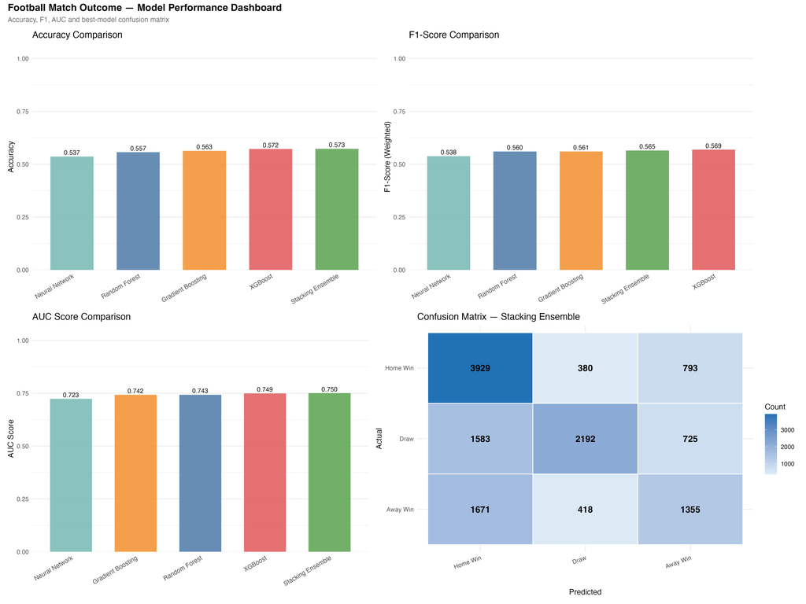

Model Performance Comparison Dashboard

```r
knitr::include_graphics(
  here("classification", "output", "model_performance_comparison.png"))
```

## 5.2 Per-Class Performance

[figure not shown]

Precision and Recall by Class and Model

```r
knitr::include_graphics(
  here("classification", "output", "per_class_performance.png"))
```

## 5.3 Feature Importance

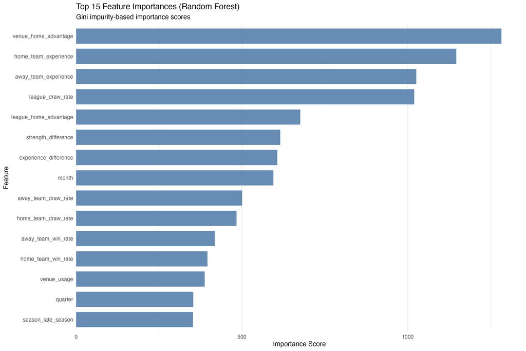

Top 15 Feature Importances (Random Forest)

```r
knitr::include_graphics(
  here("classification", "output", "feature_importance.png"))
```

# 6 Error Analysis

```r
error_text <- readLines(
  here("classification", "output", "error_analysis.txt"))
cat(paste(error_text, collapse = "\n"))
```

```
ERROR ANALYSIS REPORT
==================================================

Best Model: Stacking Ensemble
Total Errors: 5570 / 13046 (42.7%)

Home Win:
  Total samples : 5102
  Misclassified : 1173
  Error rate    : 23.0%
  Most often misclassified as: Away Win

Draw:
  Total samples : 4500
  Misclassified : 2308
  Error rate    : 51.3%
  Most often misclassified as: Home Win

Away Win:
  Total samples : 3444
  Misclassified : 2089
  Error rate    : 60.7%
  Most often misclassified as: Home Win

PYTHON BASELINE (Stacking Ensemble):
  Total Errors : 5516 / 15925 (34.6%)
  Home Win     : 33.5% error rate
  Draw         : 40.3% error rate
  Away Win     : 30.2% error rate
```

# 7 Ethical Considerations

```r
eth_text <- readLines(
  here("classification", "output", "ethical_considerations.txt"))
cat(paste(eth_text, collapse = "\n"))
```

[output not shown]

# 8 Summary & Conclusions

## 8.1 Key Findings

- **Best model:** Stacking Ensemble with **57.30%** accuracy
- **Feature engineering:** 26 features engineered including temporal, team performance, league, venue and head-to-head features
- **Class balancing:** SMOTE applied — all 3 classes balanced to 20,408 samples each
- **XGBoost** performed best among individual models

## 8.2 Comparison with Python Baseline

- Different random seed implementations between R and Python
- SMOTE implementation differences (`themis` vs `imblearn`)
- Neural Network architecture differences (`brulee`/`nnet` vs `MLPClassifier`)

## 8.3 Reproducibility Notes

- All packages pinned via `renv.lock`
- Random seeds set to 42 throughout to match Python baseline
- No absolute paths used — `here()` package used throughout
- Full pipeline runs end-to-end with single `source()` command

*Group 8 | Reproducible Research | University of Warsaw 2025-2026*